# Project 1

Tyler Hinnendael

2022-10-06

# Question 1

– to be filled out in the high-level report.

# Question 2

Prompt: a) A description of the data and the variables – created a variable “price per carat”, to combine these two features so the visualizations take into account the ‘weight’ of the diamond size in the price. b) the data visualizations you created to address how price is related to the other variables – violin plot to show distribution of mean-price against each feature – bar chart with mean price trends for each category/sub-category – bar plot to show mean-price trends for each combination of the 3 categorical variables – could not do a correlation matrix because 3 of the variables are not numeric c) the claims made on the diamond education page. – ” Cut is considered the most important of the four C’s. Color is the second most important of the 4Cs.” -> Color appears to be the most consistent feature across all observations. Cut and clarity have some influential observations and categories (flawless clarity). Cut does not appear to be the most important feature. d) Provide contextual commentary on the visualizations.

```r
## reads in the diamonds4.csv file
diamonds<-read.csv("diamonds4.csv", header=TRUE)
```

```r
# created 'price per carat" to normalize based on a wide range of carat sizes
vec<- (diamonds$price / diamonds$carat)
diamonds["price_per_carat"]<-vec
```

```r
library(ggplot2)
vars<- c("cut", "price", "price_per_carat")
dia_cut<-diamonds[vars]
#ggplot(pol1, aes(raceethnicity)) + geom_bar()
```

# (Question 2) - bar charts of mean_price and cut, color, and clarity

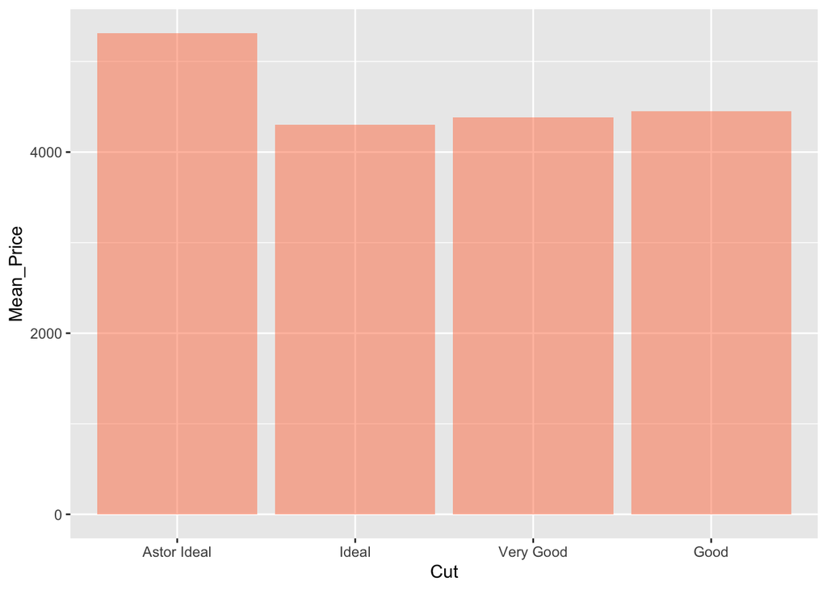

```r
cut_mean<-aggregate(diamonds$price_per_carat, list(diamonds$cut), FUN=mean)
cols <- c("Cut", "Mean_Price")
colnames(cut_mean) <- cols
cut_mean$Cut<- factor(cut_mean$Cut, levels=c("Astor Ideal", "Ideal", "Very Good", "Good"))
ggplot(cut_mean, aes(x=Cut, y=Mean_Price)) + geom_bar(stat = "identity", fill = "coral", alpha = 0.5)
```

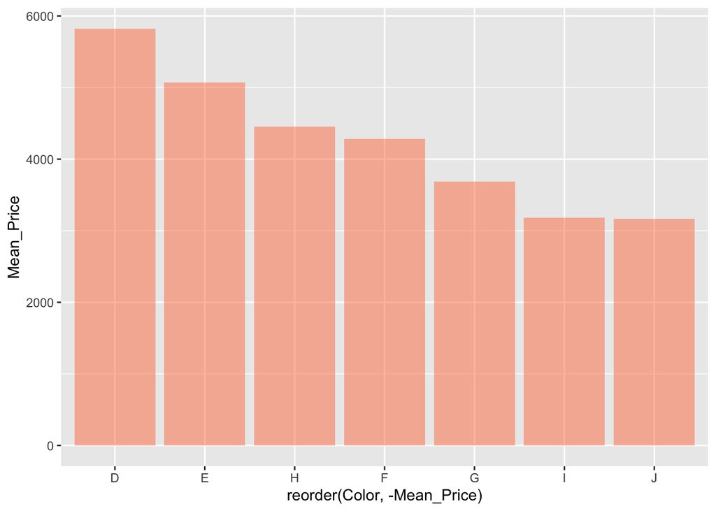

```r
color_mean<-aggregate(diamonds$price_per_carat, list(diamonds$color), FUN=mean)
cols <- c("Color", "Mean_Price")
colnames(color_mean) <- cols
ggplot(color_mean, aes(x=reorder(Color, -Mean_Price), y=Mean_Price)) + geom_bar(stat = "identity", fill = "coral", alpha = 0.5)
```

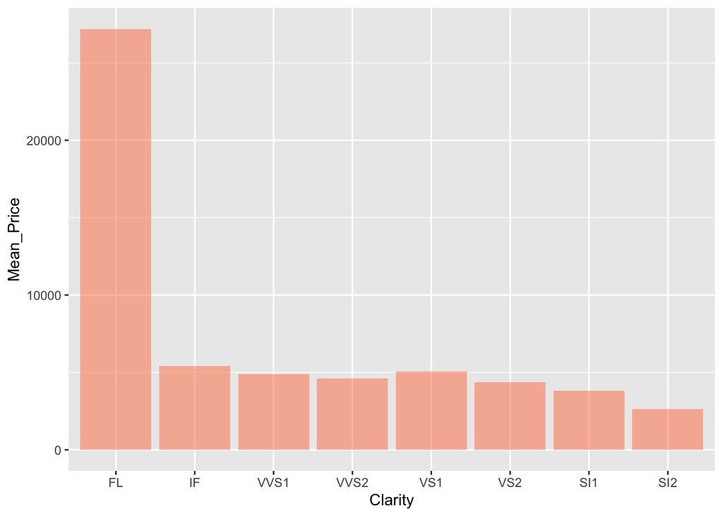

```r
clarity_mean<-aggregate(diamonds$price_per_carat, list(diamonds$clarity), FUN=mean)
cols <- c("Clarity", "Mean_Price")
colnames(clarity_mean) <- cols
clarity_mean$Clarity<- factor(clarity_mean$Clarity, levels=c("FL", "IF", "VVS1", "VVS2", "VS1", "VS2", "SI1", "SI2"))
ggplot(clarity_mean, aes(x=Clarity, y=Mean_Price)) + geom_bar(stat = "identity", fill = "coral", alpha = 0.5)
```

```r
clarity_mean$Clarity<- factor(clarity_mean$Clarity, levels=c("FL", "IF", "VVS1", "VVS2", "VS1", "VS2", "SI1", "SI2"))
```

```r
library(MASS)
library(reshape)
library(reshape2)
var_means<-aggregate(diamonds$price_per_carat, list(diamonds$cut, diamonds$color, diamonds$clarity), FUN=mean)
cols <- c("Cut", "Color", "Clarity", "Mean_Price")
colnames(var_means) <- cols
var_means$Clarity<- factor(var_means$Clarity, levels=c("FL", "IF", "VVS1", "VVS2", "VS1", "VS2", "SI1", "SI2"))
var_means$Cut<- factor(var_means$Cut, levels=c("Astor Ideal", "Ideal", "Very Good", "Good"))
```

# (Question 2) - ggplots showing trends in mean-price per carat with combinations of the 3 categorical C’s

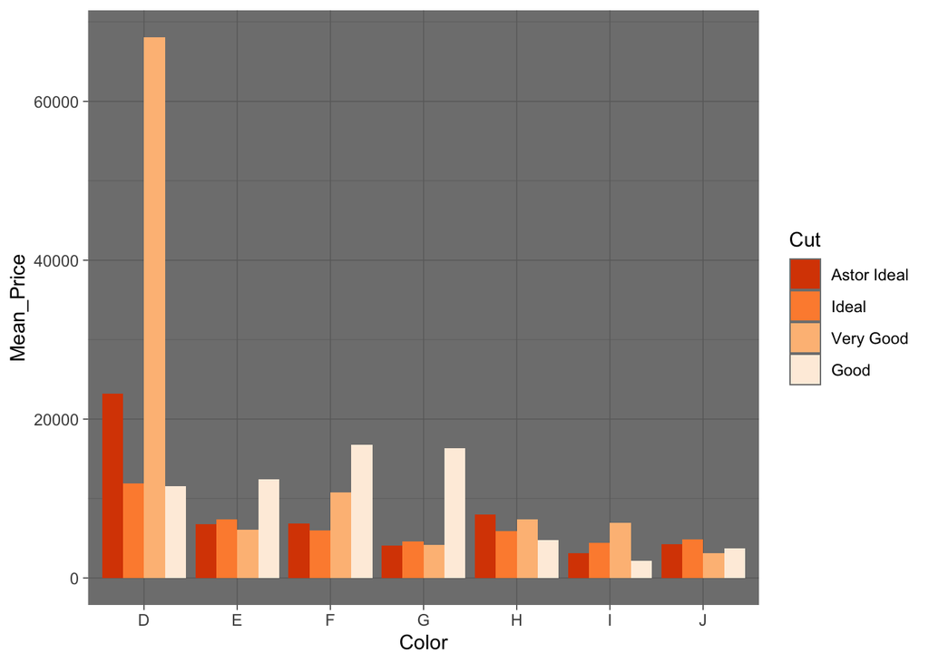

```r
p<-ggplot(var_means, aes(x=Color, y=Mean_Price, fill=Cut)) +
  geom_bar(position="dodge", stat = "identity") +
  scale_fill_brewer(palette = 7, direction = -1) +
  scale_colour_brewer(palette = 1)
p+theme_dark()
```

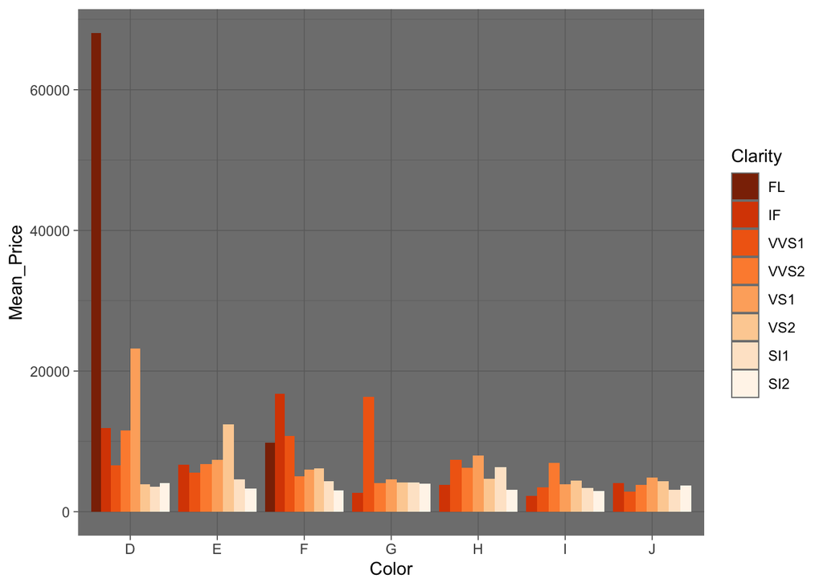

```r
p<-ggplot(var_means, aes(x=Color, y=Mean_Price, fill=Clarity)) +
  geom_bar(position="dodge", stat = "identity") +
  scale_fill_brewer(palette = 7, direction = -1) +
  scale_colour_brewer(palette = 1)
p+theme_dark()
```

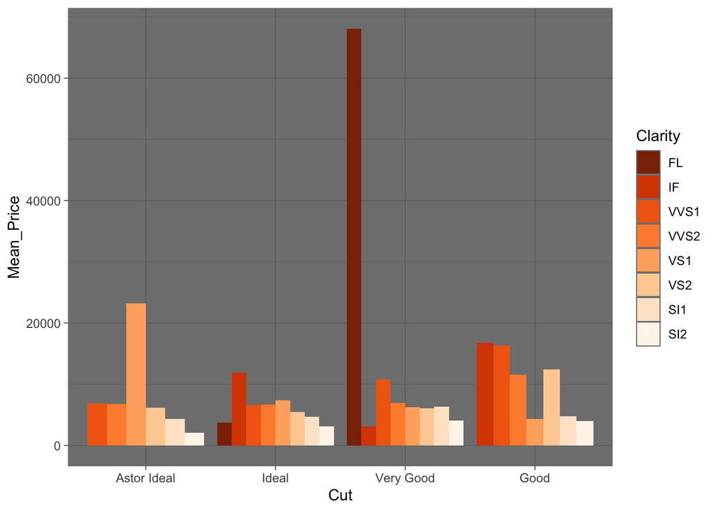

```r
p<-ggplot(var_means, aes(x=Cut, y=Mean_Price, fill=Clarity)) +
  geom_bar(position="dodge", stat = "identity") +
  scale_fill_brewer(palette = 7, direction = -1) +
  scale_colour_brewer(palette = 1)
p+theme_dark()
```

```r
diamonds$clarity<- factor(diamonds$clarity, levels=c("FL", "IF", "VVS1", "VVS2", "VS1", "VS2", "SI1", "SI2"))
diamonds$cut<- factor(diamonds$cut, levels=c("Astor Ideal", "Ideal", "Very Good", "Good"))
```

# (Question 2) - boxplots and violin plots depict the distribution of price per carat for the 3 categorical ‘C’ features.

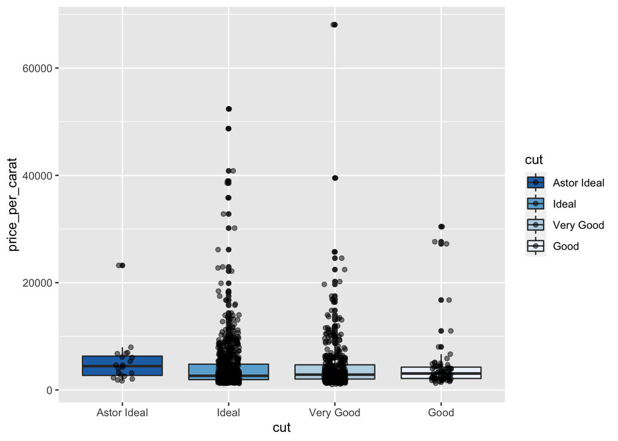

```r
par(mfrow=c(1,3))

ggplot(diamonds, aes(x=cut, y=price_per_carat, fill=cut)) +
  geom_boxplot() +
  geom_jitter(width=0.1, alpha=0.5) +
  scale_fill_brewer(palette="Blues", direction=-1)
```

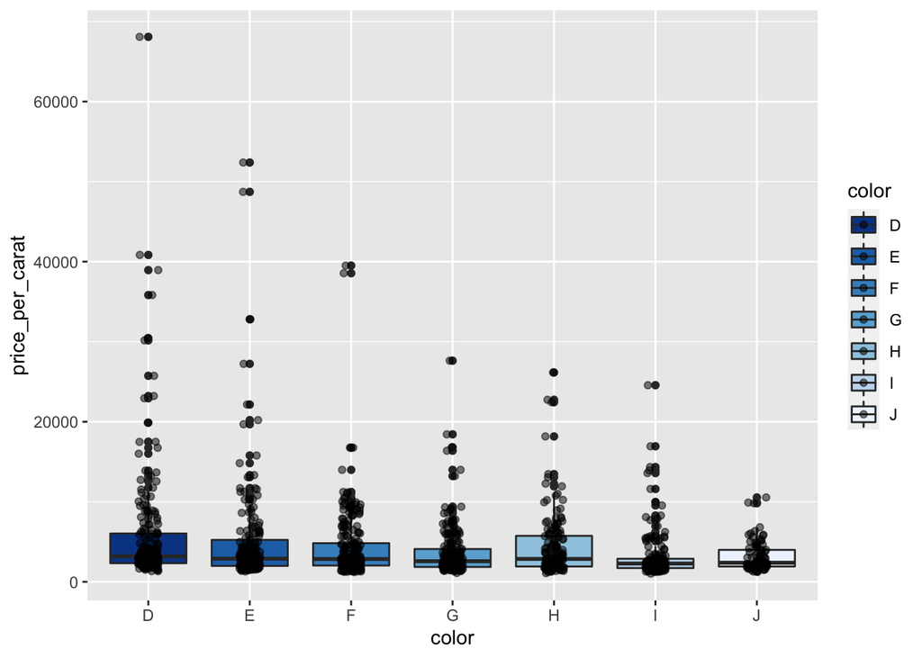

```r
ggplot(diamonds, aes(x=color, y=price_per_carat, fill=color)) +
  geom_boxplot() +
  geom_jitter(width=0.1, alpha=0.5) +
  scale_fill_brewer(palette="Blues", direction=-1)
```

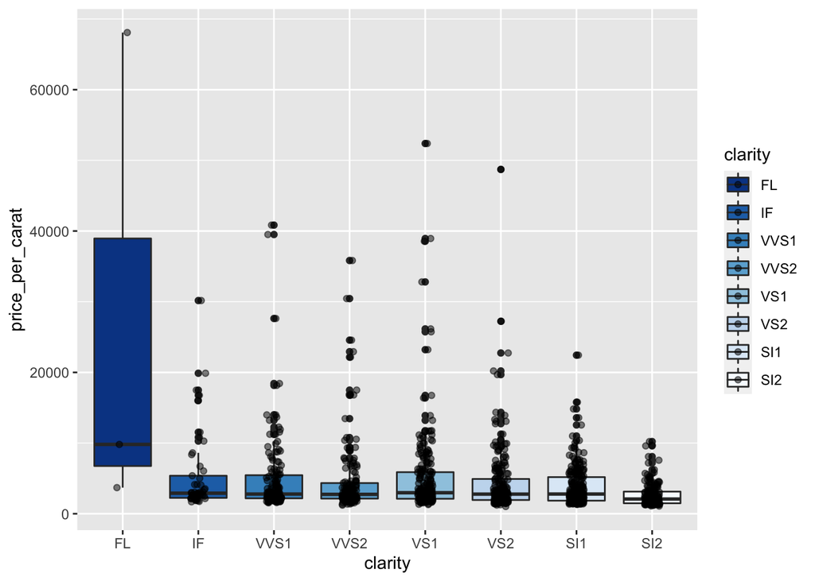

```r
ggplot(diamonds, aes(x=clarity, y=price_per_carat, fill=clarity)) +
  geom_boxplot() +
  geom_jitter(width=0.1, alpha=0.5) +
  scale_fill_brewer(palette="Blues", direction=-1)
```

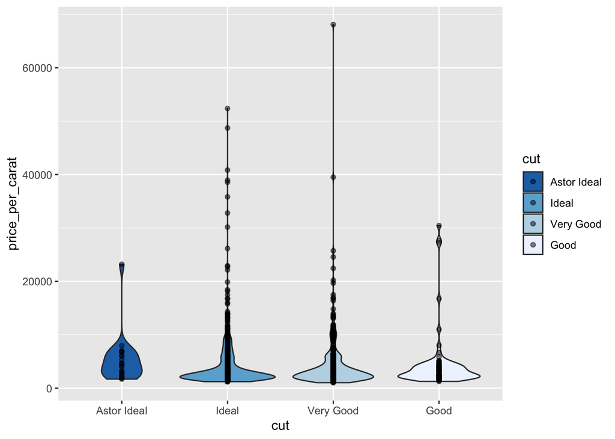

```r
par(mfrow=c(1,3))

ggplot(diamonds, aes(x=cut, y=price_per_carat, fill=cut)) +
  geom_violin() +
  geom_jitter(width=0, alpha=0.5) +
  scale_fill_brewer(palette="Blues", direction=-1)
```

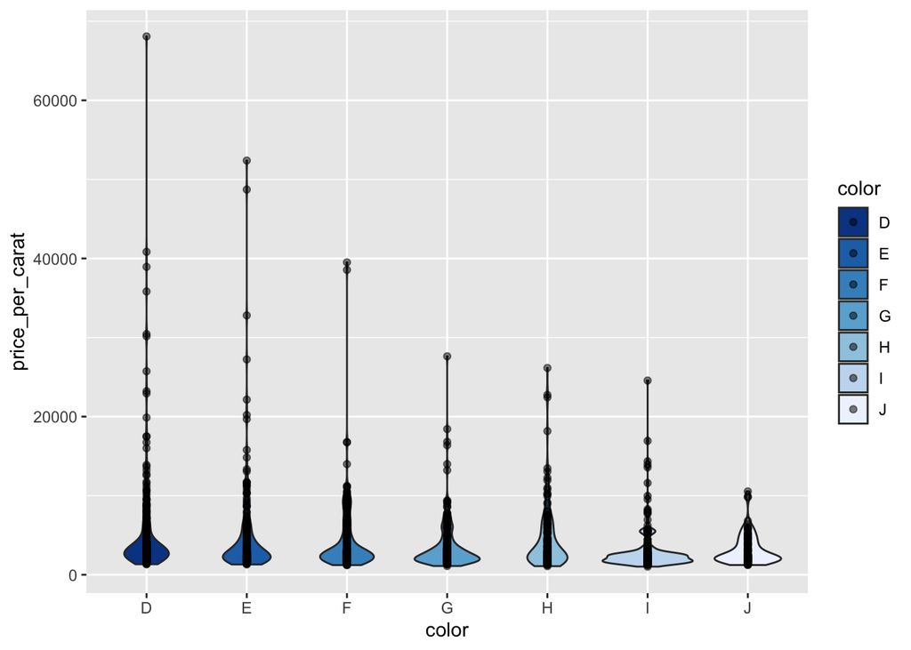

```r
ggplot(diamonds, aes(x=color, y=price_per_carat, fill=color)) +
  geom_violin() +
  geom_jitter(width=0, alpha=0.5) +
  scale_fill_brewer(palette="Blues", direction=-1)
```

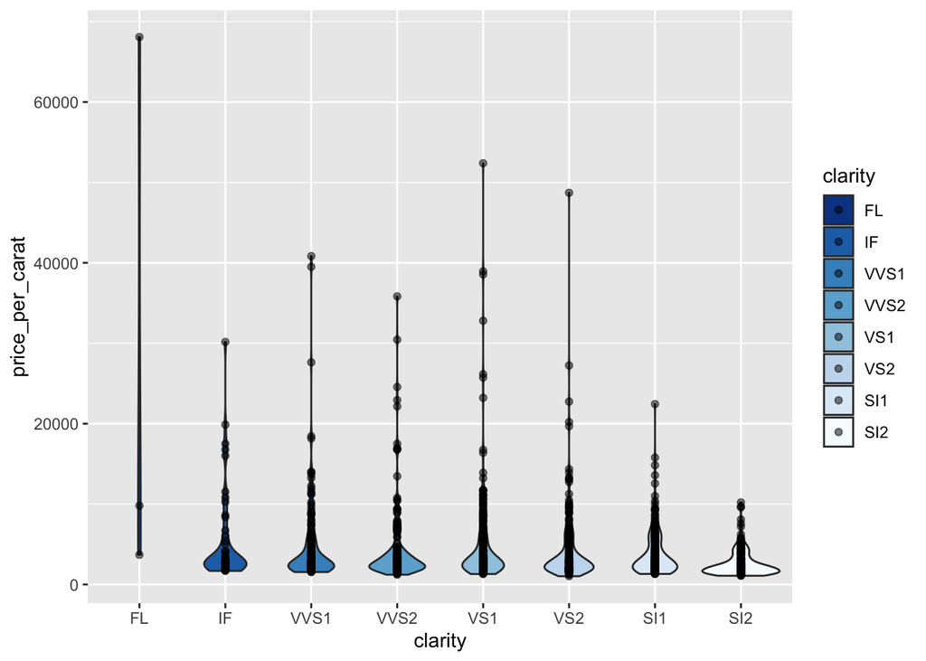

```r
ggplot(diamonds, aes(x=clarity, y=price_per_carat, fill=clarity)) +
  geom_violin() +
  geom_jitter(width=0, alpha=0.5) +
  scale_fill_brewer(palette="Blues", direction=-1)
```

```r
#var_means[var_means$Group.2 != "I" & var_means$Group.2 != "J" & var_means$Group.3 != "SI1" & var_means$Group.3 != "SI2" ,]
```

# Question 3

Prompt: “A description of how you fitted the regression of price against carat, and the conclusions reached. If possible, be sure to provide some contextual commentary on the linear regression equation that you propose.”

**(a)** Exploring the relationship between price and carat with a scatter plot.

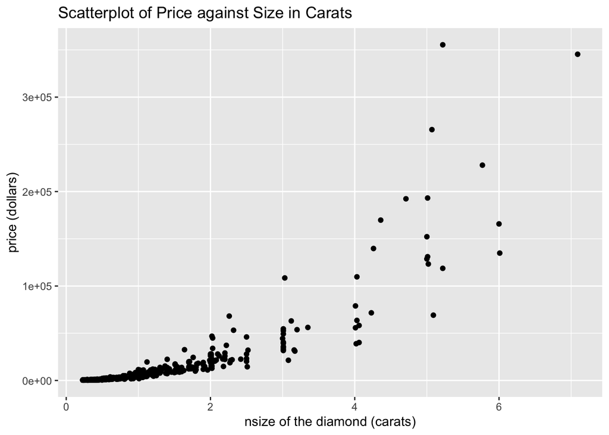

```r
ggplot(diamonds, aes(x=carat, y=price))+
  geom_point()+
  labs(x="nsize of the diamond (carats)", y="price (dollars)",
       title="Scatterplot of Price against Size in Carats")
```

**(b)** Running linear regression and assessments on residuals and possible transformations

```r
linear_result<-lm(price~carat, data=diamonds)
summary(linear_result)
```

```
##
## Call:
## lm(formula = price ~ carat, data = diamonds)
##
## Residuals:
##    Min     1Q Median     3Q    Max
## -49375  -5048   1867   4965 236711
##
## Coefficients:
##             Estimate Std. Error t value Pr(>|t|)
## (Intercept) -13550.9      559.7  -24.21   <2e-16 ***
## carat        25333.9      494.4   51.24   <2e-16 ***
## ---
## Signif. codes:  0 '***' 0.001 '**' 0.01 '*' 0.05 '.' 0.1 ' ' 1
##
## Residual standard error: 13560 on 1212 degrees of freedom
## Multiple R-squared:  0.6842, Adjusted R-squared:  0.6839
## F-statistic:  2625 on 1 and 1212 DF,  p-value: < 2.2e-16
```

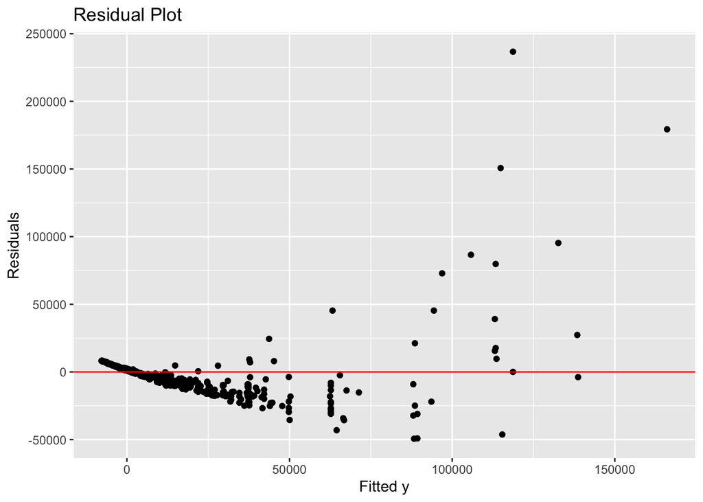

```r
yhat<-linear_result$fitted.values
res<-linear_result$residuals
diamonds<-data.frame(diamonds, yhat, res)
ggplot(diamonds, aes(x=yhat, y=res))+
  geom_point()+
  geom_hline(yintercept=0, color="red") +
  labs(x="Fitted y",
       y="Residuals",
       title="Residual Plot")
```

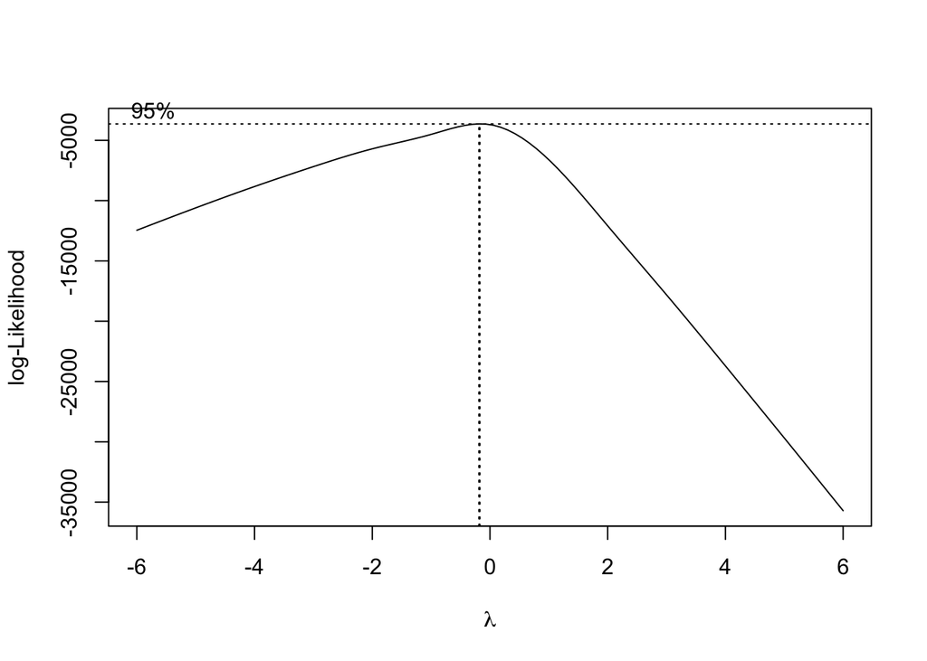

```r
library(MASS)
boxcox(linear_result, lambda = seq(-6, 6, 1))
```

**(c)** Running linear regression and assessments on residuals and possible transformations